# FoodHub_Project_1_Full_Code_Solution_Notebook

**Importing the required libraries**

```python
# Installing the libraries with the specified version.
!pip install numpy==2.0.2 pandas==2.2.2 matplotlib==3.10.0 seaborn==0.13.2 -q --user
```

```python
# import libraries for data manipulation
import numpy as np
import pandas as pd

# import libraries for data visualization
import matplotlib.pyplot as plt
import seaborn as sns
```

**Understanding the structure of the data**

```python
# uncomment and run the below code snippets if the dataset is present in the Google Drive
# from google.colab import drive
# drive.mount('/content/drive')

# ******IGNORING THIS STEP AS THE DATA SET (foodhub_order.csv) IS DIRECTLY UPLODED UNDER FILES in colab*****
```

```python
# Write your code here to read the data from csv file
df = pd.read_csv('foodhub_order.csv')
```

```python
# Write your code here to view the first 5 rows
df.head()
```

|  | order_id | customer_id | restaurant_name | cuisine_type | cost_of_the_order | day_of_the_week | rating | food_preparation_time | delivery_time |
| --- | --- | --- | --- | --- | --- | --- | --- | --- | --- |
| 0 | 1477147 | 337525 | Hangawi | Korean | 30.75 | Weekend | Not given | 25 | 20 |
| 1 | 1477685 | 358141 | Blue Ribbon Sushi Izakaya | Japanese | 12.08 | Weekend | Not given | 25 | 23 |
| 2 | 1477070 | 66393 | Cafe Habana | Mexican | 12.23 | Weekday | 5 | 23 | 28 |
| 3 | 1477334 | 106968 | Blue Ribbon Fried Chicken | American | 29.20 | Weekend | 3 | 25 | 15 |
| 4 | 1478249 | 76942 | Dirty Bird to Go | American | 11.59 | Weekday | 4 | 25 | 24 |

**Question 1: How many rows and columns are present in the data?**

```python
# Check the shape of the dataset i.e checking number of rows and columns in dataframe.
df.shape
```

```
(1898, 9)
```

Observations:There are 1898 rows and 9 columns in dataset.

**Question 2: What are the datatypes of the different columns in the dataset?**

```python
# Check the data types of columns in dataframe
df.info()
```

```
<class 'pandas.core.frame.DataFrame'>
RangeIndex: 1898 entries, 0 to 1897
Data columns (total 9 columns):
 #   Column                 Non-Null Count  Dtype
---  ------                 --------------  -----
 0   order_id               1898 non-null   int64
 1   customer_id            1898 non-null   int64
 2   restaurant_name        1898 non-null   object
 3   cuisine_type           1898 non-null   object
 4   cost_of_the_order      1898 non-null   float64
 5   day_of_the_week        1898 non-null   object
 6   rating                 1898 non-null   object
 7   food_preparation_time  1898 non-null   int64
 8   delivery_time          1898 non-null   int64
dtypes: float64(1), int64(4), object(4)
memory usage: 133.6+ KB
```

Observations:

- All the columns have 1898 observations/rows indicating that there is no missing value present for any columns ,however there are some restaurents for which ratings are not present and addressed as 'Not given' so there are some missing values in dataset.
- The order_id, customer_id, cost_of_the_order ,food_preparation_time and delivery_time columns are numerical in nature(int64/float64) rest all are object type.
- The rating column is being read as a 'object' data type but it should be numeric type integer or float , cosidering the dataset can be converted to integer as all the ratings are in whole number.

**Question 3: Are there any missing values in the data? If yes, treat them using an appropriate method.**

```python
# checking missing values across each columns
df.isnull().sum()
```

|  | 0 |
| --- | --- |
| order_id | 0 |
| customer_id | 0 |
| restaurant_name | 0 |
| cuisine_type | 0 |
| cost_of_the_order | 0 |
| day_of_the_week | 0 |
| rating | 0 |
| food_preparation_time | 0 |
| delivery_time | 0 |

**dtype:** int64

Observations:

- There are no missing values in 9 columns of the data.
- There are some restaurents for which ratings are not present and addressed as 'Not given' so this are missing values in dataset, sinces the datatype is object its not considered as missing value, we will update these missing values default to 0 in seperate column without affecting original dataframe ,this new columns added in dataframe in below code for Question : How many orders are not rated?

**Question 4: Check the statistical summary of the data. What is the minimum, average, and maximum time it takes for food to be prepared once an order is placed?**

```python
# check descriptive statistics for all numerical columns in the DataFrame
df.describe().T
```

|  | count | mean | std | min | 25% | 50% | 75% | max |
| --- | --- | --- | --- | --- | --- | --- | --- | --- |
| order_id | 1898.0 | 1.477496e+06 | 548.049724 | 1476547.00 | 1477021.25 | 1477495.50 | 1.477970e+06 | 1478444.00 |
| customer_id | 1898.0 | 1.711685e+05 | 113698.139743 | 1311.00 | 77787.75 | 128600.00 | 2.705250e+05 | 405334.00 |
| cost_of_the_order | 1898.0 | 1.649885e+01 | 7.483812 | 4.47 | 12.08 | 14.14 | 2.229750e+01 | 35.41 |
| food_preparation_time | 1898.0 | 2.737197e+01 | 4.632481 | 20.00 | 23.00 | 27.00 | 3.100000e+01 | 35.00 |
| delivery_time | 1898.0 | 2.416175e+01 | 4.972637 | 15.00 | 20.00 | 25.00 | 2.800000e+01 | 33.00 |

Observations: Once's an order is placed Minimum food preparation time is 20 minutes , Maximum food preparation time is 35 minutes and Average food preparation time is 27.37 minutes.

**Question 5: How many orders are not rated?**

```python
# Counts the occurrences of each unique value in the 'rating' column of a DataFrame
df['rating'].value_counts()
```

| rating | count |
| --- | --- |
| Not given | 736 |
| 5 | 588 |
| 4 | 386 |
| 3 | 188 |

**dtype:** int64

```python
# Creating missing values for rating column default to 0 in seperate column without affecting original dataframe
# and creating copy of data in newdataframe.
newdataframe = df.copy()
newdataframe['int_column_rating'] = newdataframe['rating'].replace(['missing','Not given'],0)

# changing the data type to integer
newdataframe['int_column_rating']  = newdataframe['int_column_rating'].astype(int)

# drop rating columns as all rating values are copied to new cloumn : int_column_rating and save it to newdataframe
newdataframe = newdataframe.drop('rating', axis=1)

# Counts the occurrences of each unique value in the new column 'int_column_rating' of a newdataframe
newdataframe['int_column_rating'].value_counts()
```

| int_column_rating | count |
| --- | --- |
| 0 | 736 |
| 5 | 588 |
| 4 | 386 |
| 3 | 188 |

**dtype:** int64

Observations : There are 736 orders which are not rated.

In the above code we have created the copy of actual dataframe df and stored it to data which is a new dataset having new column 'int_column_rating' where Not Given values are replaced by 0 and datatype is changed to integer which are copied from rating column without impacting old dataframe and from new dataframe we have droped rating column as all values are copied to new column int_column_rating.

### Exploratory Data Analysis (EDA)

### Univariate Analysis

**Question 6: Explore all the variables and provide observations on their distributions. (Generally, histograms, boxplots, countplots, etc. are used for univariate exploration.)**

```python
# check unique values of order ID
newdataframe['order_id'].nunique()
```

```
1898
```

Observations:There are 1898 unique order Ids.

```python
# check unique values of customer_id
newdataframe['customer_id'].nunique()
```

```
1200
```

Observations:There are 1200 unique customer ids.

```python
# check unique values of restaurant_name
newdataframe['restaurant_name'].nunique()
```

```
178
```

Observations:There are 178 unique restaurant names.

```python
# check unique values of cuisine_type
newdataframe['cuisine_type'].unique()
```

```
array(['Korean', 'Japanese', 'Mexican', 'American', 'Indian', 'Italian',
       'Mediterranean', 'Chinese', 'Middle Eastern', 'Thai', 'Southern',
       'French', 'Spanish', 'Vietnamese'], dtype=object)
```

Observations:There are 14 unique cuisine types.

```python
# check unique values of day_of_the_week
newdataframe['day_of_the_week'].unique()
```

```
array(['Weekend', 'Weekday'], dtype=object)
```

Observations:The days of weeks are weekend and weekday.

```python
# check unique values of int_column_rating as we are referring new dataset
newdataframe['int_column_rating'].unique()
```

```
array([0, 5, 3, 4])
```

Observations:The ratings values are : 0,3,4,5 where 'Not Given' was replaced with 0 in new dataset.

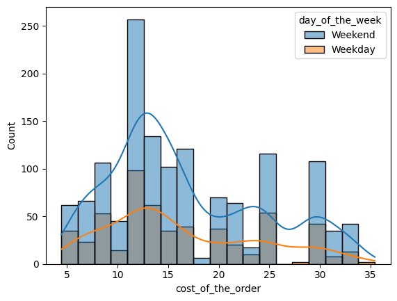

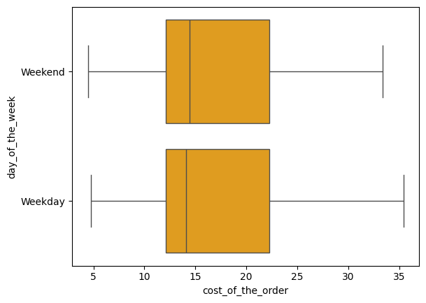

```python
# create a histogram for cost of order based on day_of_the_week
sns.histplot(data = newdataframe, x='cost_of_the_order', kde=True, hue='day_of_the_week')
plt.show()

# Create a Boxplot for the cost of order based on day_of_the_week
sns.boxplot(data = newdataframe ,x='cost_of_the_order' , y='day_of_the_week', color='orange')
plt.show()
```

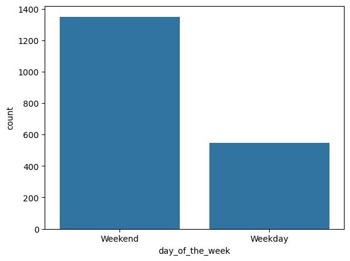

```python
# Plotted a bar graph for 'day_of_the_week' column
sns.countplot(x ='day_of_the_week', data = newdataframe);
```

Observations:The countplot bar graph shows weekend and weekdays orders counts , which clearly states that the orders on weekend are more (around 1350 orders on weekend) then weekdays.

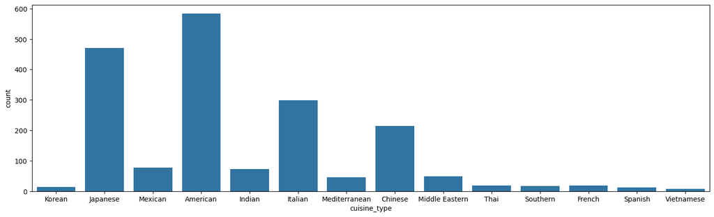

```python
# Plotted a bar graph for 'cuisine_type' column
plt.figure(figsize=(18,5))
cp = sns.countplot(data = newdataframe, x = 'cuisine_type');
```

Observations:The count plot bar graph on cuisine type show that the Japanese,American, Italian ,Chinese cuisine have more orders and popular onces. The Indian and Mexican cuisine are also popular but the order are less then 100 for both. However the other cuisine like Korean , thai, french,spanish,Vietnamese have very less orders and should try selling most ordered cuisine like Japanese , American etc.

```python
# displayed the order counts of cuisine type
newdataframe['cuisine_type'].value_counts()
```

| cuisine_type | count |
| --- | --- |
| American | 584 |
| Japanese | 470 |
| Italian | 298 |
| Chinese | 215 |
| Mexican | 77 |
| Indian | 73 |
| Middle Eastern | 49 |
| Mediterranean | 46 |
| Thai | 19 |
| French | 18 |
| Southern | 17 |
| Korean | 13 |
| Spanish | 12 |
| Vietnamese | 7 |

**dtype:** int64

Observations : Here in this table displyed the order counts of cuisine types , which show there are maximum order for American cuisine : 584 and minimum order for Vietnamese cuisine : 7.

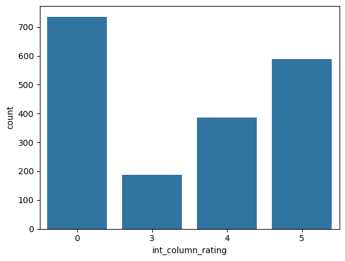

```python
# Plotted a bar graph for 'rating' column
sns.countplot(data = newdataframe , x= 'int_column_rating');
```

Observations : As per the countplot bar graph there are more ratings for 5 and no ratings under 3.

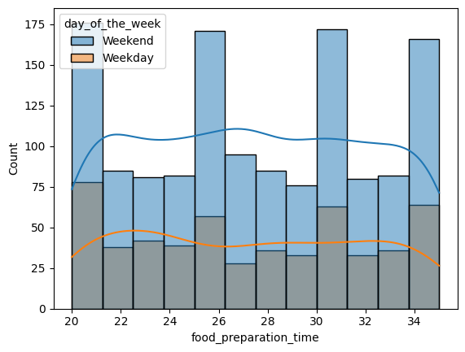

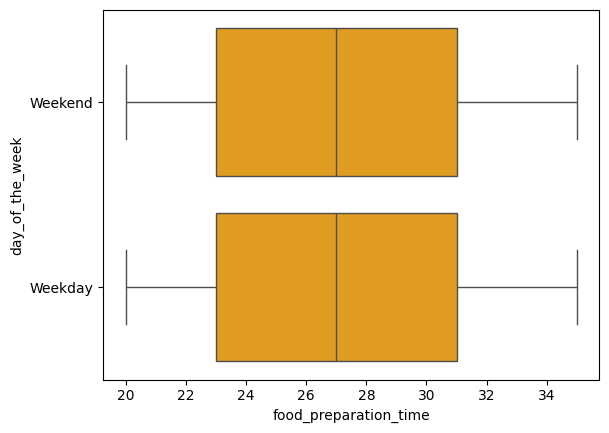

```python
#Create a histogram for food_preparation_time
sns.histplot(data = newdataframe, x='food_preparation_time' ,kde = True , hue='day_of_the_week')
plt.show()

#Create a boxplot for food_preparation_time
sns.boxplot(data = newdataframe,x='food_preparation_time', y= 'day_of_the_week', color='orange')
plt.show()
```

Observations : Food preparation time are similar for weekdays and weekends, having no skew and approximatly balanced distribution with median at 27 minutes.

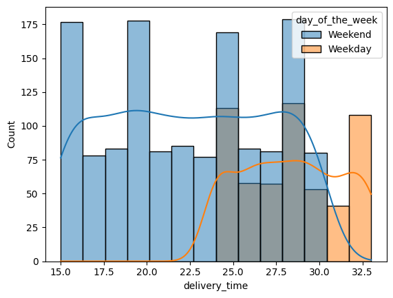

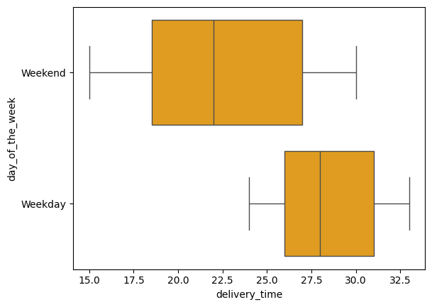

```python
#Create a histogram for delivery_time
sns.histplot(data = newdataframe, x='delivery_time' ,kde = True , hue='day_of_the_week')
plt.show()

#Create a boxplot for delivery_time
sns.boxplot(data = newdataframe,x='delivery_time', y= 'day_of_the_week', color='orange')
plt.show()
```

Observations : Here in the graph shows that delivery time is higher during weekdays as compared to weekend , most of the orders are delivered within 27 mins very less in 30 mins for weekend.This could be due to trafic conditions.

**Question 7: Which are the top 5 restaurants in terms of the number of orders received?**

```python
# Top 5 restaurants with highest number of orders
newdataframe['restaurant_name'].value_counts().head(5)
```

| restaurant_name | count |
| --- | --- |
| Shake Shack | 219 |
| The Meatball Shop | 132 |
| Blue Ribbon Sushi | 119 |
| Blue Ribbon Fried Chicken | 96 |
| Parm | 68 |

**dtype:** int64

Observations: Above table show the top 5 restaurants with numbers of order received , here Shake Shack restaurant has maximum orders of count 219 and restaurant Parm has minimum order of 68.

**Question 8: Which is the most popular cuisine on weekends?**

```python
# Get most popular cuisine on weekends
df_weekend = newdataframe[newdataframe['day_of_the_week'] == 'Weekend']
df_weekend['cuisine_type'].value_counts()
```

| cuisine_type | count |
| --- | --- |
| American | 415 |
| Japanese | 335 |
| Italian | 207 |
| Chinese | 163 |
| Mexican | 53 |
| Indian | 49 |
| Middle Eastern | 32 |
| Mediterranean | 32 |
| Thai | 15 |
| French | 13 |
| Korean | 11 |
| Southern | 11 |
| Spanish | 11 |
| Vietnamese | 4 |

**dtype:** int64

Observations: American cuisine is most popular on weekends having order count of 415.

**Question 9: What percentage of the orders cost more than 20 dollars?**

```python
# get all orders that cost more than 20 dollars
df_order_greater_than_20 = newdataframe[newdataframe['cost_of_the_order']>20]

# df_order_greater_than_20.shape[0] is total number of order that cost more than 20 dollars and calculated the percentage of orders.
percentage = (df_order_greater_than_20.shape[0] / newdataframe.shape[0]) * 100

print("Percentage of orders more than 20 dollars:", round(percentage, 2), '%')
```

```
Percentage of orders more than 20 dollars: 29.24 %
```

Observations: 29.24% of orders cost more than 20 dollar which states that rest 70 % approx order are less than 20 dollar so there are large number of order which are less than 20 dollar.

**Question 10: What is the mean order delivery time?**

```python
# get mean delivery time
mean_delivery_time = newdataframe['delivery_time'].mean()

print('The mean delivery time for dataset is', round(mean_delivery_time, 2), 'minutes')
```

```
The mean delivery time for dataset is 24.16 minutes
```

Observations:24.16 minutes is the mean order delivery time.

**Question 11: The company has decided to give 20% discount vouchers to the top 3 most frequent customers. Find the IDs of these customers and the number of orders they placed.**

```python
# Get the top 3 most frequesnt customer and number of order they placed
df['customer_id'].value_counts().head(3)
```

| customer_id | count |
| --- | --- |
| 52832 | 13 |
| 47440 | 10 |
| 83287 | 9 |

**dtype:** int64

Observations: The top three most frequent Customers are customer: 52832 with 13 orders ,customer: 47440 with 10 orders and customer: 83287 with 9 orders.

Multivariate Analysis

**Question 12: Perform a multivariate analysis to explore relationships between the important variables in the dataset. (It is a good idea to explore relations between numerical variables as well as relations between numerical and categorical variables)**

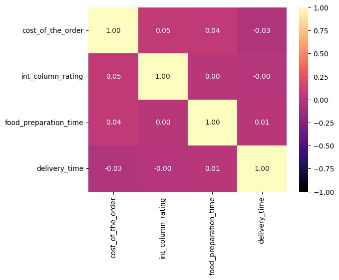

```python
# Created the heatmap graph to get correlation between numerical columns
sns.heatmap(data = newdataframe[["cost_of_the_order","int_column_rating","food_preparation_time","delivery_time"]].corr(),annot=True, vmin=-1, vmax=1, fmt=".2f", cmap="magma");

plt.show()
```

Observation : The correlation matrix show the week correlation between variables.

Relationship between Cost of the order and cuisine type

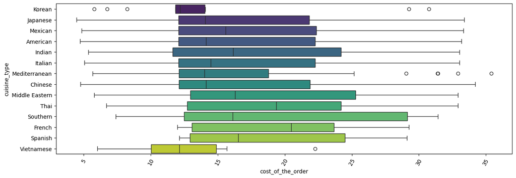

```python
# Plot a graph to show relationship between cost of the order and cuisine type
plt.figure(figsize=(15,5))
sns.boxplot(x = "cost_of_the_order", y = "cuisine_type", data = newdataframe, palette = 'viridis', hue = "cuisine_type")
plt.xticks(rotation = 60)
plt.show()
```

However there are some less ordered cuisine as well having the higher cost , they could try reducing cost of such cuisine if that could increase the sale, required more research here.

For Korean,Vietnamese and Mediterranean cuisine outlier are present.

Relationship between Ratings and cuisine type

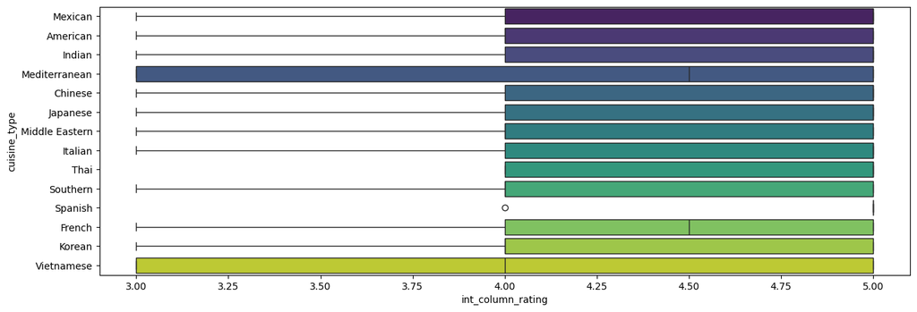

```python
# Plot a graph to show relationship between cost of the order and cuisine type
plt.figure(figsize=(15,5))
sns.boxplot(x = "int_column_rating", y = "cuisine_type", data = newdataframe[newdataframe['int_column_rating']!=0], palette = 'viridis', hue = "cuisine_type")
plt.show()
```

Relationship between Ratings and Delivery time

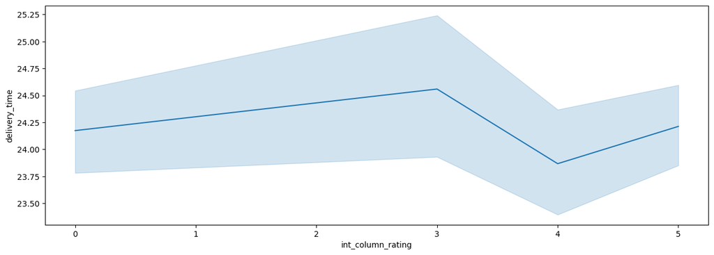

```python
# Plot a graph to show relationship between rating and delivery
plt.figure(figsize=(15, 5))
sns.lineplot(x = 'int_column_rating', y = 'delivery_time', data = newdataframe)
plt.show()
```

Observations:The graph show the relationship between the rating and delivery time , here for rating 3 the delivery time is at peak of around 24.55 minutes.

For rating 4 has lowest delivery time of 23.88 minutes than again delivery time slightly increases for rating 5 for around 24.2 minutes.

Relationship between Rating and Food preparation time

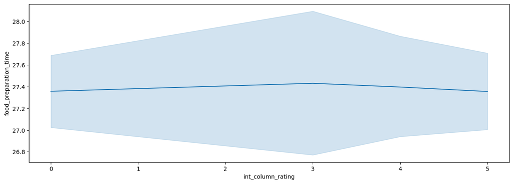

```python
# Plot a graph to show relationship between rating and Food preparation time
plt.figure(figsize=(15, 5))
sns.lineplot(x = 'int_column_rating', y = 'food_preparation_time', data = newdataframe)
plt.show()
```

Observations:The graph show the relationship between food preparation time and rating , here the average food preparation time is unaffected by the rating column, there was just slight peaks around rating 3 at about 27.42 minutes but overall average preparation time is unaffected.So for any rating there is almost no influence on how long it takes to make the food.

Relationship between Rating and Cost of the order

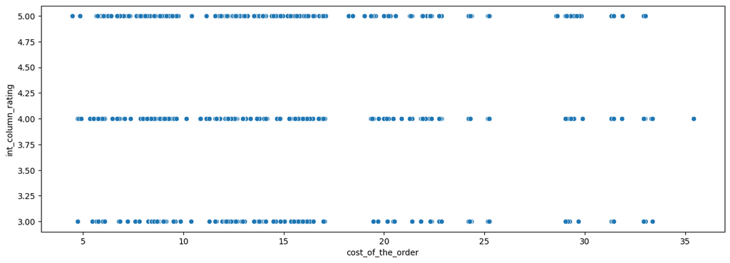

```python
# Plot a graph to show relationship between rating and Food preparation time
plt.figure(figsize=(15, 5))
sns.scatterplot(x = 'cost_of_the_order', y = 'int_column_rating', data = newdataframe[newdataframe['int_column_rating']!=0])
plt.show()
```

Observations: This graph shows relationship between cost of order and rating , Only rating 3 ,4 and 5 is provided for restaurents. The data for ratings 0, 1, and 2 is excluded not present in this dataset.

Orders at rating 3 are also widely distributed across the cost spectrum (x -axis ), similar to ratings 4 and 5.

So the cost of an order is not a determining factor for the rating it receives even it is highest.

Relationship between Day of the Week and Delivery time

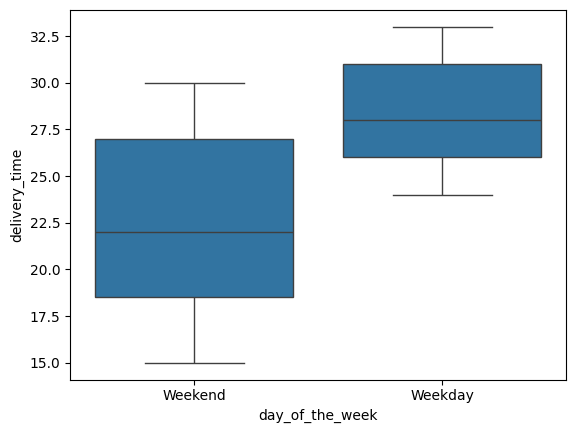

```python
# Plot a graph to show relationship between day of week and delivery time
sns.boxplot(x = "day_of_the_week", y = "delivery_time", data = newdataframe)
plt.show()
```

Observations: The graph show the relationship between the days of week and delivery time , there are slower deliveries on Weekdays since the median is at approx 28 min slower than on Weekends which is approx 22 mins. So the delivery time is slower on weekdays could be due to factors like traffic or higher business volume.

**Question 13: The company wants to provide a promotional offer in the advertisement of the restaurants. The condition to get the offer is that the restaurants must have a rating count of more than 50 and the average rating should be greater than 4. Find the restaurants fulfilling the criteria to get the promotional offer.**

```python
#As we have already created the copy of dataframe to newdataframe
#converted rating columns as int and replaced all NOT Given rating to 0 , we will use same newdataframe with column int_column_rating.

# filter all 0 rating columns from data frame
filter_all_0_ratings = newdataframe[newdataframe['int_column_rating']!= 0]

# Create a dataframe that contains the restaurant names with their rating counts
dataframe_rating_count = filter_all_0_ratings.groupby(['restaurant_name'])['int_column_rating'].count().sort_values(ascending = False).reset_index()

# Display top 5 rows of dataframe
dataframe_rating_count.head()
```

|  | restaurant_name | int_column_rating |
| --- | --- | --- |
| 0 | Shake Shack | 133 |
| 1 | The Meatball Shop | 84 |
| 2 | Blue Ribbon Sushi | 73 |
| 3 | Blue Ribbon Fried Chicken | 64 |
| 4 | RedFarm Broadway | 41 |

```python
# Get Restaurant names that have rating count more than 50
restaurant_name = dataframe_rating_count[dataframe_rating_count['int_column_rating'] > 50]['restaurant_name']

# Create a copy of dataframe to get all the restaurants that have rating count more than 50 checking restaurant present in restaurant_name dataframe.
dataframe_mean = filter_all_0_ratings[filter_all_0_ratings['restaurant_name'].isin(restaurant_name)].copy()

#Find the mean rating of each restaurant grouping them by restaurant name and rating column
dataframe_mean_4_rating = dataframe_mean.groupby(['restaurant_name'])['int_column_rating'].mean().sort_values(ascending = False).reset_index()

# Get the average rating greater than 4
df_avg_rating_greater_than_4 = dataframe_mean_4_rating[dataframe_mean_4_rating['int_column_rating'] > 4].sort_values(by='restaurant_name', ascending=False).reset_index(drop=True)

# Merge the dataframe having restaurant names, count of rating (in below table shown in column :int_column_rating_x)
# and rating greater than four average (in below table shown in column :int_column_rating_y)
merged_dataframe = pd.merge(dataframe_rating_count, df_avg_rating_greater_than_4, on='restaurant_name')

#This merged dataframe gives all restaurant name on which promotional offer can be provided as the required criteria is achieved for this reataurants.
merged_dataframe
```

|  | restaurant_name | int_column_rating_x | int_column_rating_y |
| --- | --- | --- | --- |
| 0 | Shake Shack | 133 | 4.278195 |
| 1 | The Meatball Shop | 84 | 4.511905 |
| 2 | Blue Ribbon Sushi | 73 | 4.219178 |
| 3 | Blue Ribbon Fried Chicken | 64 | 4.328125 |

Observations:This merged dataframe above gives all restaurant name on which promotional offer can be provided as the required criteria is achieved for the restaurants : Shake Shack, The Meatball Shop ,Blue Ribbon Sushi and Blue Ribbon Fried Chicken ,this all restaurants have rating count more than 50 orders (shown in column :int_column_rating_x) and the average rating is greater than 4 (shown in column :int_column_rating_y).

**Question 14: The company charges the restaurant 25% on the orders having cost greater than 20 dollars and 15% on the orders having cost greater than 5 dollars. Find the net revenue generated by the company across all orders.**

```python
#Code to determine the revenue
def check_revenue(x):
    if x > 20:
        return x*0.25
    elif x > 5:
        return x*0.15
    else:
        return x*0

# call the check_revenue function to get restaurants having revenue greater than 20 and greater than 5
# by using cost_of_the_order columns on dataframe and add revenue colums in dataframe
newdataframe['Revenue'] = newdataframe['cost_of_the_order'].apply(check_revenue)

# Get the total revenue and store in variable total_rev and print the total revenue
total_rev = newdataframe['Revenue'].sum()
print('The net revenue is around $',total_rev)
```

```
The net revenue is around $ 6166.303
```

Observations: The net revenue is around $6166.303 across all orders.

**Question 15: The company wants to analyze the total time required to deliver the food. What percentage of orders take more than 60 minutes to get delivered from the time the order is placed? (The food has to be prepared and then delivered.)**

```python
# Calculate total delivery time and add a new column to the newdataframe  to store the total delivery time
newdataframe['total_time'] = newdataframe['food_preparation_time'] + newdataframe['delivery_time']

#Get all the deliveries over 60 mins
deliveries_value_over_60_minutes = len(newdataframe[newdataframe['total_time'] > 60])

#Get the percentage of deliveries taking longer time than 60 minutes.
percentage_of_long_order = deliveries_value_over_60_minutes/len(newdataframe)*100

#print the percentage of orders taking more than 60 minutes time to get deliveried.
print(round(percentage_of_long_order,2),"% of orders takes more than 60 minutes to get delivered from the time the order is placed")
```

```
10.54 % of orders takes more than 60 minutes to get delivered from the time the order is placed
```

Observations:10.54 % of orders takes more than 60 minutes to get delivered from the time the order is placed.

**Question 16: The company wants to analyze the delivery time of the orders on weekdays and weekends. How does the mean delivery time vary during weekdays and weekends?**

```python
#Get the mean delivery time for Weekday and Weekend for all orders.
mean_delivery_time = df.groupby('day_of_the_week')['delivery_time'].agg(['mean','count'])

#Display the mean_delivery_time for both weekdays and weekend for all orders.
mean_delivery_time
```

| day_of_the_week | mean | count |
| --- | --- | --- |
| Weekday | 28.340037 | 547 |
| Weekend | 22.470022 | 1351 |

Observations: Mean time of delivery is less for weekends and higher for the Weekdays though the orders are less on weekdays and more on weekends,the time could be higher on weekdays due to traffic conditions or higher business volume.

### Conclusion and Recommendations

**Question 17: What are your conclusions from the analysis? What recommendations would you like to share to help improve the business? (You can use cuisine type and feedback ratings to drive your business recommendations.)**

**Conclusions :**

My key findings of FoodHub’s Project with respect to restaurant performance/ratings , customer satisfaction, operational efficiency, cost includes below points :

Preparation & Delivery Time

1. 10.54% of orders take more than 60 minutes to get delivered from the time the order is placed, this could give negative impact to customers.
2. Mean time of delivery is less for weekends and higher for the Weekdays though the orders are less on weekdays and more on weekends,the time could be higher on weekdays due to traffic conditions or higher business volume.
3. The average food preparation time is unaffected by the rating column.

**Recommendations:**

Preparation & Delivery Time

1. Weekday delivery delays can be Optimized by explore better delivery schedules and traffic optimized routs.
2. Identify the restaurants taking more delivery time and work with them to improve food preparation and delivery time.
3. Promote the restaurants which have high ratings and good performance to improve customer satisfaction which likely get us more orders.

Customer Offers for Restaurant & Cuisine Type

1. The Restaurants which are getting less order should try selling cuisine which are most ordered like Japanese, American etc.
2. Inform customer about orders which are taking more than 60 mins in delivery which can save customer time and provide improved communication.
3. For higher ratings restaurants should provide some discounts to customer.

Increased Revenue

1. Highlight the most ordered and high rated cuisines on online portal to get more orders of this cuisine.
2. Low efficient restaurants which are taking more preparation and delivery time should work with them to sort out efficiency.